# Exploratory Data Analysis

Author

Michael Love

Published

July 19, 2025

## Introduction

Exploratory data analysis (EDA), including data inspection and visualization, is a key component of data analysis. Performing routine statistical analysis such as linear modeling or statistical tests, without examination of data, can result in incorrect scientific inference, both in the direction of false findings and missed discoveries, i.e. false positives and negatives.

In this document, we will walk through some common EDA steps as part of the analysis of a particular genomics dataset. No particular genomics knowledge is required for this lecture note, and any additional information that is useful for examining the data will be provided during the data exploration. As with any data, learning a bit about the expected relationships is useful, so feel free to consult e.g. Wikipedia or other sources.

We will start with basic data import and high-level plots, then move on to more advanced analyses such as principal components analysis (PCA), concluding with some specific genome-focused analysis, and complex manipulation of the data, organized into a rich data object. We will describe how organizing data into objects helps EDA and can help to avoid common bookkeeping errors.

## Reading and looking at data

### The Alasoo *et al.* 2018 dataset

To find meaningful patterns in data, we need to first consider a bit about how they were generated, and the experimental design.

In this document, I will work through examples from summary data associated with a particular experiment, published in 2018:

> Alasoo K, Rodrigues J, Mukhopadhyay S, Knights AJ, Mann AL, Kundu K; HIPSCI Consortium; Hale C, Dougan G, Gaffney DJ. Shared genetic effects on chromatin and gene expression indicate a role for enhancer priming in immune response. Nat Genet. 2018 Mar;50(3):424-431. doi: 10.1038/s41588-018-0046-7. Epub 2018 Jan 29. PMID: 29379200; PMCID: PMC6548559.

https://pubmed.ncbi.nlm.nih.gov/29379200/

The key experiment design is described in this section:

> We focussed on enhancer priming in the context of human macrophage immune response. To ensure sufficient numbers of cells, we differentiated macrophages from a panel of 123 human induced pluripotent cell lines (iPSCs) obtained from the HipSci project. We profiled gene expression (RNA-seq) and chromatin accessibility (ATAC-seq) in a subset of 86 successfully differentiated lines … in four experimental conditions: naive (N), 18 hours IFNγ stimulation (I), 5 hours Salmonella enterica serovar Typhimurium (Salmonella) infection (S), and IFNγ stimulation followed by Salmonella infection (I+S).

To restate, the authors used *induced stem cell lines*, differentiated these into *macrophage-like cells* (so capable of immune response), and then subjected the cells to three *treatments* (plus control condition), in order to explore the cellular immune response. Key considerations to the experimental design here:

1. Different human donors will have different genotypes, and so can be used to study genetic effects on immune response.
2. Interferon gamma (IFNg or IFNγ) stimulation primes the immune system to respond to Salmonella infection, and so may show a different effect than each treatment alone.

In the summary data we will work with, we do not have genotype information, so we will ignore this aspect of the data (the paper is very interesting and focuses on this, so do read further if you are interested). The full data is available but requires an formal application to be submitted for data use.

### A bit of omics background

**Overview:** We will look at data that summarizes the *RNA-seq* and *ATAC-seq*, in cell lines from diverse human donors, across four experimental conditions. If these experiments are not familiar, all we need to know is that RNA-seq measures the expression of genes, and ATAC-seq measures the accessibility of chromatin across the genome. They use DNA sequencing machines to make these measurements, but that detail is not critical right now. Accessibility is another word for the chromatin being less compact, such that the DNA is more open and available to DNA-binding proteins. Compact chromatin is less accessible for DNA-binding proteins.

**Motivation:** We are interested in measuring the average accessibility of chromatin across cells in the sample, as these DNA-binding proteins often mediate cellular response by binding to specific DNA sequences and influencing transcription of genes on the same chromosomes (referred to as *cis* in genetics for occurring on the same molecule) and “nearby” in the linear molecule. These DNA-binding proteins could be called regulatory proteins, or “transcription factors”, and the piece of DNA that they bind to could be called a regulatory element, or more specifically a *cis*-regulatory element (CRE). For our purposes, “nearby” on the chromosome may mean 10-100 thousands of basepairs in either direction from the location that the protein binds. For interpreting this paragraph, take a look at panels [Fig 1a and 1b](https://www.ncbi.nlm.nih.gov/core/lw/2.0/html/tileshop_pmc/tileshop_pmc_inline.html?title=Alasoo%202018&p=PMC3&id=6548559_EMS83143-f001.jpg) in the published article.

**Data interpretation:** The data will consist of counts organized into a matrix. The arrangement of the matrix is described below, but I first describe at a high level, the meaning of the counts that appear within. A count in the matrix is an observation of particular region of DNA being *accessible* in a particular sample. The measurements are *relative* in that the total count for one sample across all the regions is basically arbitrary. A zero or a low count means that the region was *less accessible* than a region with a higher count, within a sample.

### File descriptions

Summary versions of the expression and chromatin accessibility data are available here:

https://zenodo.org/records/1188300

I have downloaded a few of these files and made small versions of them in this git repository. I subset the chromatin accessibility (ATAT-seq) data to the first 1000 rows. In this data a row corresponds to a region of the genome (a potential regulatory element). Columns will correspond to samples (human cell lines in one of the treatment conditions). There are three important files:

1. the count matrix describing accessibility
2. the genome regions being described (rows of the matrix). these happen to be called “peaks”
3. the samples being assayed (columns of the matrix)

### Reading in data

Let’s start by reading in the counts matrix. Two packages used here:

1. *readr* for reading in the files
2. *here* for referring to local files

```r
library(readr)
library(here)
counts <- read_delim(here("exploratory/counts.txt.gz"))
counts
```

```
# A tibble: 1,000 × 146
   peak         bima_A_ATAC bima_B_ATAC bima_C_ATAC bima_D_ATAC eofe_A_ATAC eofe_B_ATAC eofe_C_ATAC
   <chr>              <dbl>       <dbl>       <dbl>       <dbl>       <dbl>       <dbl>       <dbl>
 1 ATAC_peak_1          283         278         325         282         303         436         391
 2 ATAC_peak_2           24         216          44          75          42          77          84
 3 ATAC_peak_3           33          54          36          23          20          23          28
 4 ATAC_peak_4           44          44          65          36          42          25          39
 5 ATAC_peak_5           24          23          17          10          13           9          11
 6 ATAC_peak_6           32          32          33          19          31          15          21
 7 ATAC_peak_7          370         560         537         431         327         380         479
 8 ATAC_peak_8           26          20          23          11          15          17          20
 9 ATAC_peak_9           27          24          22          17          44          29          31
10 ATAC_peak_10          11          29          54          43          13          57          53
# ℹ 990 more rows
# ℹ 138 more variables: eofe_D_ATAC <dbl>, eika_B_ATAC <dbl>, eika_A_ATAC <dbl>, ieki_B_ATAC <dbl>,
#   ieki_A_ATAC <dbl>, nusw_B_ATAC <dbl>, nusw_A_ATAC <dbl>, ruyv_B_ATAC <dbl>, ruyv_A_ATAC <dbl>,
#   uimo_B_ATAC <dbl>, uimo_A_ATAC <dbl>, cicb_B_ATAC <dbl>, cicb_A_ATAC <dbl>, cicb_D_ATAC <dbl>,
#   cicb_C_ATAC <dbl>, vass_B_ATAC <dbl>, vass_A_ATAC <dbl>, vass_D_ATAC <dbl>, vass_C_ATAC <dbl>,
#   oefg_B_ATAC <dbl>, oefg_A_ATAC <dbl>, veqz_B_ATAC <dbl>, veqz_A_ATAC <dbl>, pahc_B_ATAC <dbl>,
#   pahc_A_ATAC <dbl>, sukz_B_ATAC <dbl>, sukz_A_ATAC <dbl>, xucm_B_ATAC <dbl>, …
```

The last line prints the tibble to the console which shows the first 10 rows in this case, and then states the remaining number of rows. We see a selection of the columns, which are samples.

```r
library(readr)
peaks <- read_delim(here("exploratory/peaks.txt.gz"))
peaks
```

```
# A tibble: 1,000 × 9
   gene_id      length percentage_gc_content   chr start   end strand score gene_name
   <chr>         <dbl>                 <dbl> <dbl> <dbl> <dbl> <chr>  <dbl> <chr>
 1 ATAC_peak_1     690                 0.555     1  9979 10668 +       1000 ATAC_peak_1
 2 ATAC_peak_2     535                 0.675     1 10939 11473 +       1000 ATAC_peak_2
 3 ATAC_peak_3     225                 0.618     1 15505 15729 +       1000 ATAC_peak_3
 4 ATAC_peak_4     334                 0.572     1 21148 21481 +       1000 ATAC_peak_4
 5 ATAC_peak_5     204                 0.559     1 21864 22067 +       1000 ATAC_peak_5
 6 ATAC_peak_6     149                 0.544     1 26026 26174 +       1000 ATAC_peak_6
 7 ATAC_peak_7     822                 0.718     1 28665 29486 +       1000 ATAC_peak_7
 8 ATAC_peak_8     105                 0.676     1 29745 29849 +       1000 ATAC_peak_8
 9 ATAC_peak_9     159                 0.509     1 29935 30093 +       1000 ATAC_peak_9
10 ATAC_peak_10    328                 0.415     1 33060 33387 +       1000 ATAC_peak_10
# ℹ 990 more rows
```

And the sample information, in a file referring to “column data”, because the columns of the matrix are samples:

```r
coldata <- read_delim(here("exploratory/coldata.txt.gz"))
coldata
```

```
# A tibble: 145 × 47
   sample_id   donor condition_char condition_name SL1344   IFNg   stimulation_date submission_date
   <chr>       <chr> <chr>          <chr>          <chr>    <chr>  <date>           <date>
 1 bima_A_ATAC bima  A              naive          control  naive  2014-12-12       2015-01-20
 2 bima_B_ATAC bima  B              IFNg           control  primed 2014-12-12       2015-01-20
 3 bima_C_ATAC bima  C              SL1344         infected naive  2014-12-12       2015-01-20
 4 bima_D_ATAC bima  D              IFNg_SL1344    infected primed 2014-12-12       2015-01-20
 5 eofe_A_ATAC eofe  A              naive          control  naive  2014-12-12       2015-01-20
 6 eofe_B_ATAC eofe  B              IFNg           control  primed 2014-12-12       2015-01-20
 7 eofe_C_ATAC eofe  C              SL1344         infected naive  2014-12-12       2015-01-20
 8 eofe_D_ATAC eofe  D              IFNg_SL1344    infected primed 2014-12-12       2015-01-20
 9 eika_B_ATAC eika  B              IFNg           control  primed 2015-04-17       2015-05-20
10 eika_A_ATAC eika  A              naive          control  naive  2015-04-17       2015-05-20
# ℹ 135 more rows
# ℹ 39 more variables: i5_tag <chr>, i5_sequence <chr>, i7_tag <chr>, i7_sequence <chr>,
#   nextera_tag <chr>, multiplex_pool <dbl>, bioanalyzer <chr>, nextera_kit <chr>, line_id <chr>,
#   clone <dbl>, replicate <dbl>, ips_received <date>, ips_started <date>, passage_received <dbl>,
#   received_as <chr>, media <chr>, EB_formation <date>, passage_diff <dbl>, diff_start <date>,
#   salmonella_date <date>, atac_date <date>, flow_date <date>, medium_changes <dbl>,
#   terminated <date>, status <chr>, mean_purity <dbl>, max_purity <dbl>, genotype_id <chr>, …
```

**NoteQuestion**

How many experiments do you spot per cell line donor?

We now have three pieces of data in our R session, but each alone doesn’t tell us that much. We will see as we step through the analysis that it is more convenient to tie these tables together.

## Quick summaries

We can use the `glimpse()` function from the *dplyr* package for quick summaries of the dataset. *dplyr* also provides many useful utilities for subsetting and manipulating tabular data, which we will see later.

```r
library(dplyr)
peaks <- peaks |> rename(perc_gc = percentage_gc_content)
dplyr::glimpse(peaks)
```

```
Rows: 1,000
Columns: 9
$ gene_id   <chr> "ATAC_peak_1", "ATAC_peak_2", "ATAC_peak_3", "ATAC_peak_4", "ATAC_peak_5", "ATAC…
$ length    <dbl> 690, 535, 225, 334, 204, 149, 822, 105, 159, 328, 214, 89, 192, 212, 203, 355, 2…
$ perc_gc   <dbl> 0.555072, 0.674766, 0.617778, 0.571856, 0.558824, 0.543624, 0.717762, 0.676190, …
$ chr       <dbl> 1, 1, 1, 1, 1, 1, 1, 1, 1, 1, 1, 1, 1, 1, 1, 1, 1, 1, 1, 1, 1, 1, 1, 1, 1, 1, 1,…
$ start     <dbl> 9979, 10939, 15505, 21148, 21864, 26026, 28665, 29745, 29935, 33060, 38626, 8809…
$ end       <dbl> 10668, 11473, 15729, 21481, 22067, 26174, 29486, 29849, 30093, 33387, 38839, 881…
$ strand    <chr> "+", "+", "+", "+", "+", "+", "+", "+", "+", "+", "+", "+", "+", "+", "+", "+", …
$ score     <dbl> 1000, 1000, 1000, 1000, 1000, 1000, 1000, 1000, 1000, 1000, 1000, 1000, 1000, 10…
$ gene_name <chr> "ATAC_peak_1", "ATAC_peak_2", "ATAC_peak_3", "ATAC_peak_4", "ATAC_peak_5", "ATAC…
```

Note that the first column “gene_id” is a misnomer (wrong name), as we are not looking at genes. This sometimes happens in genomics, when a file format is re-used for other types of data.

Another useful package for summarizing data is *skimr* with the `skim()` function:

```r
library(skimr)
skim(peaks)
```

Data summary

| Name | peaks |
| --- | --- |
| Number of rows | 1000 |
| Number of columns | 9 |
| _______________________ |  |
| Column type frequency: |  |
| character | 3 |
| numeric | 6 |
| ________________________ |  |
| Group variables | None |

**Variable type: character**

| skim_variable | n_missing | complete_rate | min | max | empty | n_unique | whitespace |
| --- | --- | --- | --- | --- | --- | --- | --- |
| gene_id | 0 | 1 | 11 | 14 | 0 | 1000 | 0 |
| strand | 0 | 1 | 1 | 1 | 0 | 1 | 0 |
| gene_name | 0 | 1 | 11 | 14 | 0 | 1000 | 0 |

**Variable type: numeric**

| skim_variable | n_missing | complete_rate | mean | sd | p0 | p25 | p50 | p75 | p100 | hist |
| --- | --- | --- | --- | --- | --- | --- | --- | --- | --- | --- |
| length | 0 | 1 | 306.00 | 223.28 | 52.00 | 167.00 | 232.00 | 367.50 | 1529.00 | ▇▂▁▁▁ |
| perc_gc | 0 | 1 | 0.59 | 0.11 | 0.31 | 0.51 | 0.59 | 0.67 | 0.88 | ▁▆▇▅▁ |
| chr | 0 | 1 | 1.00 | 0.00 | 1.00 | 1.00 | 1.00 | 1.00 | 1.00 | ▁▁▇▁▁ |
| start | 0 | 1 | 3984249.02 | 2660147.44 | 9979.00 | 1553756.25 | 3502116.50 | 6493686.00 | 8373970.00 | ▇▆▃▅▆ |
| end | 0 | 1 | 3984554.02 | 2660146.36 | 10668.00 | 1553961.00 | 3502247.00 | 6493817.00 | 8374329.00 | ▇▆▃▅▆ |
| score | 0 | 1 | 1000.00 | 0.00 | 1000.00 | 1000.00 | 1000.00 | 1000.00 | 1000.00 | ▁▁▇▁▁ |

**NoteQuestion**

Look at the histograms for the numeric variable table. How would you describe the distribution of the different numeric columns? Do these distributions make sense? Note that our subset of the data contains just the first 1,000 regions on chromosome 1.

We will also run `skim` on the column data, focusing on the numeric variables. We do this twice: once on the data after de-selecting the columns `assigned` and `peak_count`, and once just on those two columns. This is because the scale of those two columns is much larger than the other numberic columns, so it helps with printing to isolate them.

```r
coldata |>
  select(where(is.numeric)) |>
  select(!c(assigned, peak_count)) |>
  skim()
```

Data summary

| Name | select(select(coldata, wh… |
| --- | --- |
| Number of rows | 145 |
| Number of columns | 16 |
| _______________________ |  |
| Column type frequency: |  |
| numeric | 16 |
| ________________________ |  |
| Group variables | None |

**Variable type: numeric**

| skim_variable | n_missing | complete_rate | mean | sd | p0 | p25 | p50 | p75 | p100 | hist |
| --- | --- | --- | --- | --- | --- | --- | --- | --- | --- | --- |
| multiplex_pool | 0 | 1.00 | 2.91 | 1.24 | 0.00 | 2.00 | 3.00 | 4.00 | 4.00 | ▁▂▂▅▇ |
| clone | 0 | 1.00 | 1.95 | 1.14 | 1.00 | 1.00 | 2.00 | 3.00 | 6.00 | ▇▃▁▁▁ |
| replicate | 0 | 1.00 | 1.03 | 0.16 | 1.00 | 1.00 | 1.00 | 1.00 | 2.00 | ▇▁▁▁▁ |
| passage_received | 0 | 1.00 | 32.21 | 6.53 | 16.00 | 28.00 | 33.00 | 37.00 | 44.00 | ▁▅▅▇▅ |
| passage_diff | 0 | 1.00 | 36.41 | 6.48 | 20.00 | 32.00 | 37.00 | 41.00 | 48.00 | ▁▅▆▇▃ |
| medium_changes | 0 | 1.00 | 7.23 | 1.47 | 5.00 | 6.00 | 7.00 | 8.00 | 11.00 | ▇▆▅▃▂ |
| mean_purity | 4 | 0.97 | 0.97 | 0.02 | 0.89 | 0.96 | 0.98 | 0.99 | 1.00 | ▁▁▂▃▇ |
| max_purity | 4 | 0.97 | 0.98 | 0.02 | 0.90 | 0.97 | 0.98 | 0.99 | 1.00 | ▁▁▁▃▇ |
| ips_culture_days | 0 | 1.00 | 20.30 | 6.53 | 5.00 | 16.00 | 19.00 | 23.00 | 41.00 | ▂▇▆▂▁ |
| passage_diff_bins | 0 | 1.00 | 32.00 | 6.62 | 20.00 | 30.00 | 30.00 | 40.00 | 40.00 | ▂▁▇▁▅ |
| max_purity_filtered | 4 | 0.97 | 0.98 | 0.02 | 0.90 | 0.97 | 0.98 | 0.99 | 1.00 | ▁▁▁▃▇ |
| mean_purity_filtered | 4 | 0.97 | 0.97 | 0.02 | 0.89 | 0.96 | 0.98 | 0.99 | 1.00 | ▁▁▂▃▇ |
| assigned_frac | 0 | 1.00 | 0.54 | 0.13 | 0.19 | 0.46 | 0.58 | 0.65 | 0.76 | ▂▃▆▇▆ |
| mt_frac | 0 | 1.00 | 0.30 | 0.14 | 0.07 | 0.19 | 0.28 | 0.40 | 0.79 | ▇▇▅▂▁ |
| percent_duplication | 0 | 1.00 | 0.09 | 0.03 | 0.05 | 0.08 | 0.09 | 0.11 | 0.21 | ▅▇▂▁▁ |
| short_long_ratio | 0 | 1.00 | 2.11 | 1.03 | 0.91 | 1.47 | 1.82 | 2.42 | 6.96 | ▇▂▁▁▁ |

Note that the meaning of the columns is described in a metadata file at the Zenodo link.

**NoteQuestion**

The `assigned_frac` column is described as the “fraction of non-mitochondrial reads assigned to consensus peaks”. A “read” is an observation of accessibility in this context. What is a typical value? For a typical sample, are most of the observations within the regions called “peaks”?

```r
coldata |>
  select(assigned, peak_count) |>
  skim()
```

Data summary

| Name | select(coldata, assigned,… |
| --- | --- |
| Number of rows | 145 |
| Number of columns | 2 |
| _______________________ |  |
| Column type frequency: |  |
| numeric | 2 |
| ________________________ |  |
| Group variables | None |

**Variable type: numeric**

| skim_variable | n_missing | complete_rate | mean | sd | p0 | p25 | p50 | p75 | p100 | hist |
| --- | --- | --- | --- | --- | --- | --- | --- | --- | --- | --- |
| assigned | 0 | 1 | 15385402.5 | 5507593.4 | 3964874 | 11189997 | 15141993 | 19250016 | 31712153 | ▃▇▇▃▁ |
| peak_count | 0 | 1 | 139919.5 | 34779.3 | 37015 | 116645 | 147211 | 164249 | 208337 | ▁▂▆▇▃ |

**NoteQuestion**

What is the general number of peaks for a typical sample? Is the distribution of number of peaks left or right skewed? The `assigned` column gives the “total number of paired-end fragments overlapping peaks”, that is the number of observations that are within the regions called “peaks”. What is a typical value here? Recall that the total number of observations per sample is arbitrary. This `assigned` number is influenced both by the total number of observations and by the enrichment of observations in the “peak” regions.

Note that we can also select by pattern, see `?select` for more details:

```r
coldata |> select(ends_with("_date"))
```

```
# A tibble: 145 × 5
   stimulation_date submission_date salmonella_date atac_date  flow_date
   <date>           <date>          <date>          <date>     <date>
 1 2014-12-12       2015-01-20      2014-12-12      2014-12-12 2014-12-16
 2 2014-12-12       2015-01-20      2014-12-12      2014-12-12 2014-12-16
 3 2014-12-12       2015-01-20      2014-12-12      2014-12-12 2014-12-16
 4 2014-12-12       2015-01-20      2014-12-12      2014-12-12 2014-12-16
 5 2014-12-12       2015-01-20      2014-12-12      2014-12-12 2014-12-04
 6 2014-12-12       2015-01-20      2014-12-12      2014-12-12 2014-12-04
 7 2014-12-12       2015-01-20      2014-12-12      2014-12-12 2014-12-04
 8 2014-12-12       2015-01-20      2014-12-12      2014-12-12 2014-12-04
 9 2015-04-17       2015-05-20      2015-04-14      2015-04-17 2015-04-13
10 2015-04-17       2015-05-20      2015-04-14      2015-04-17 2015-04-13
# ℹ 135 more rows
```

## Cumulative densities, histograms, ggplot2

Above we saw small text-based histograms of numeric data, which allow us to quickly look at the distribution of values. Here I explore that further, first introducing the `ecdf()` function. An *empirical cumulative density function* shows similar information to a histogram, as if the bars of the histogram were stacking on top of each other from left to right. But instead of breaking the range of the data on the x-axis into bins, each data point is represented. The value on the y-axis goes from 0 on the left edge of the data (minimum) to 1 on the right edge of the data (maximum). Reading the x-value where the y-value equals 0.5 gives the median.

Let’s make some ECDF plots for the 1,000 rows of the count data. For example, the column sums (in thousands):

```r
dim(counts)
```

```
[1] 1000  146
```

```r
counts[1:5,1:5]
```

```
# A tibble: 5 × 5
  peak        bima_A_ATAC bima_B_ATAC bima_C_ATAC bima_D_ATAC
  <chr>             <dbl>       <dbl>       <dbl>       <dbl>
1 ATAC_peak_1         283         278         325         282
2 ATAC_peak_2          24         216          44          75
3 ATAC_peak_3          33          54          36          23
4 ATAC_peak_4          44          44          65          36
5 ATAC_peak_5          24          23          17          10
```

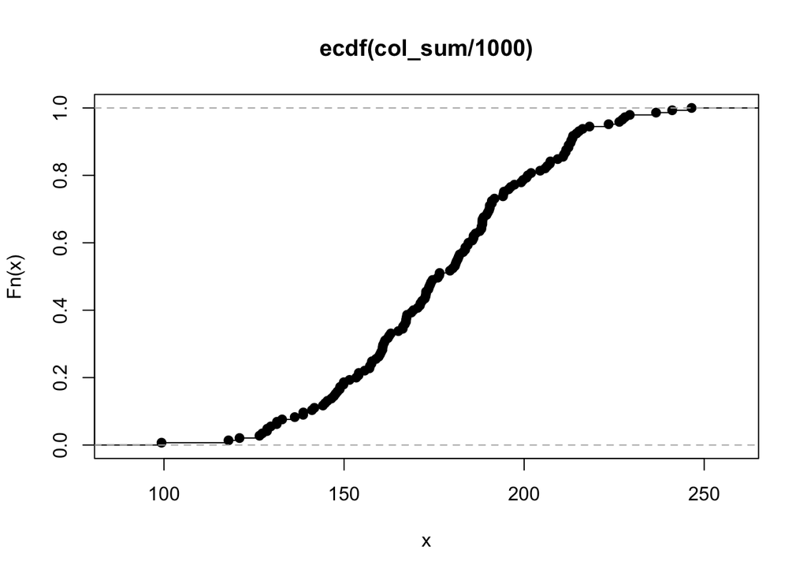

```r
col_sum <- counts |> select(-peak) |> colSums()
plot( ecdf(col_sum/1e3) )
```

**NoteQuestion**

What is a typical value for the column sum of our counts matrix?

Let’s also look at row sums (in thousands). These are the total number of observations in a region of the genome across all samples.

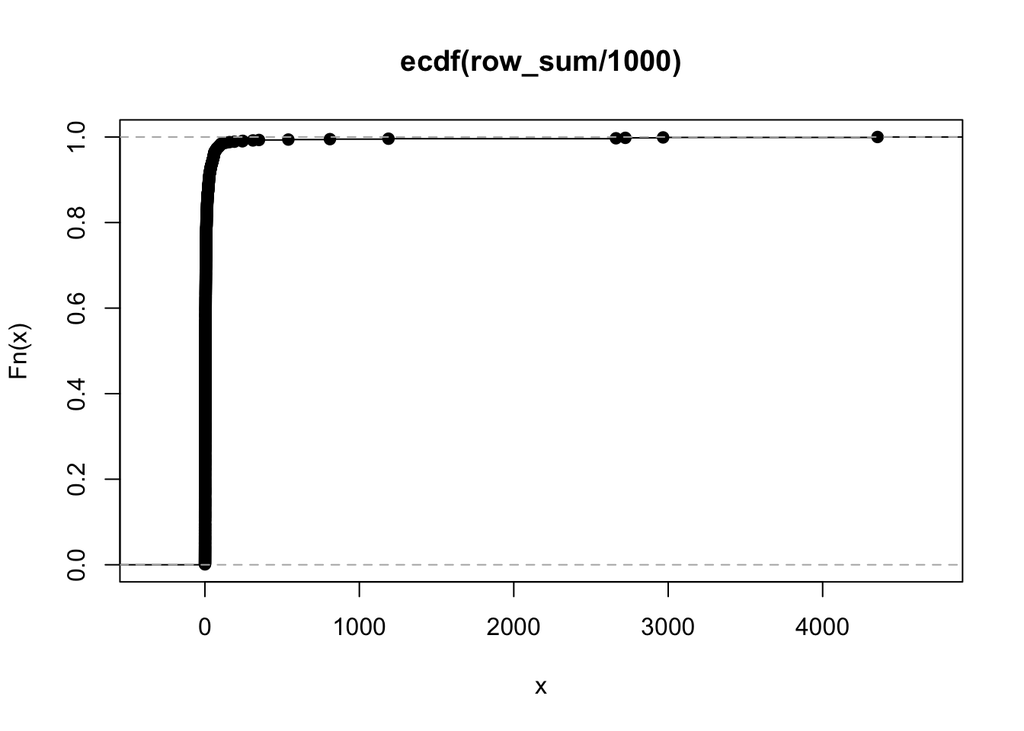

```r
row_sum <- counts |> select(-peak) |> rowSums()
plot( ecdf(row_sum/1e3) )
```

**NoteQuestion**

What do you notice about the row sum in contrast to the column sum? Any outliers?

We can focus on the area where most of the rows are:

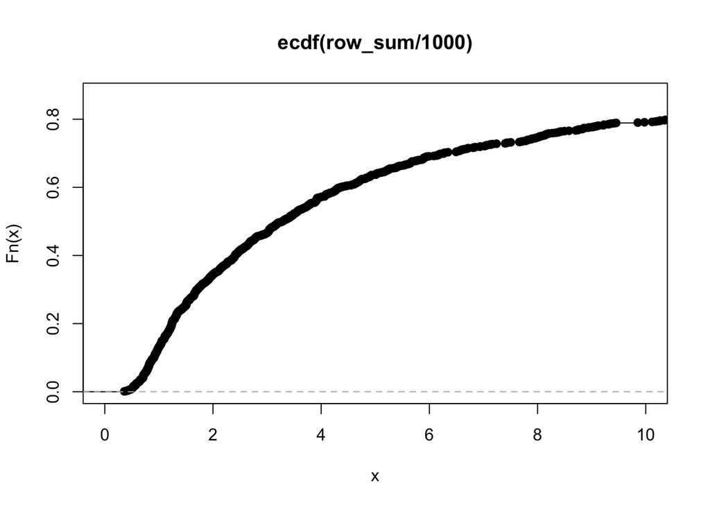

```r
plot( ecdf(row_sum/1e3), xlim=c(0,10) )
```

**NoteQuestion**

What’s a typical value for the row sum?

Another powerful package for making plots is *ggplot2*. This package is widely used and has many tutorials online. The “gg” stands for Grammar of Graphics, which refers the concept of splitting apart specification of plotting elements from the mapping of the variables to visual aesthetics. I find the best way to learn is by trying it out.

The `ggplot()` function requires input in the form of a tibble or dataframe. This is because it uses the names of the columns (variables) in mapping to the aesthetics.

In order to plot a histogram of the column sums, we first need to put this variable into a tibble, which is done on the first line below.

Then we call `ggplot()`, giving it the tibble, and in the second argument we *map* the column sum in thousands to the `x` aesthetic, within the function `aes()`.

Finally we specify a “geometry” for the data, in this case a histogram. In *ggplot2* we combine these operations with `+`.

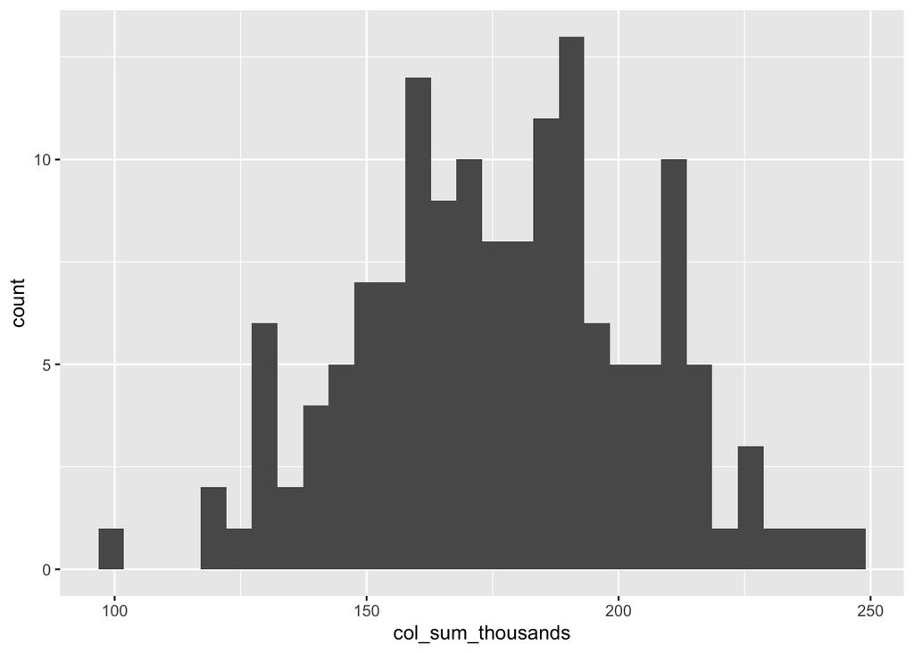

```r
library(ggplot2)
dat <- tibble(col_sum_thousands = col_sum / 1e3)
ggplot(
  data = dat,
  mapping = aes(x = col_sum_thousands)
) +
  geom_histogram()
```

This time we leave off the names of the first and second argument of `ggplot`.

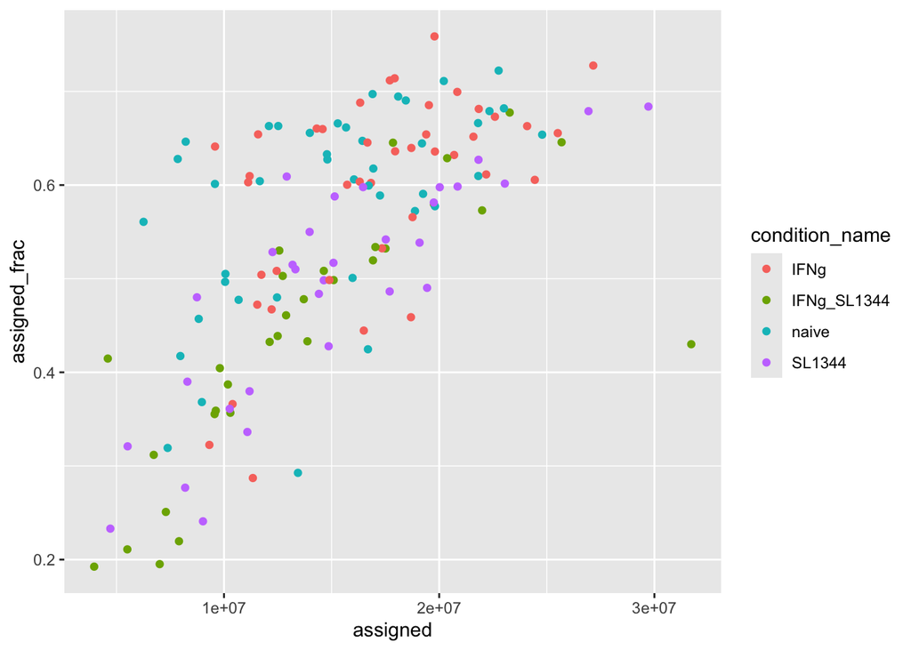

```r
ggplot(
  coldata,
  aes(x = assigned, y = assigned_frac, color = condition_name)
) +
  geom_point()
```

**NoteQuestion**

Check out the possible `geoms` at [this link](https://ggplot2.tidyverse.org/reference/index.html#geoms). Try different plots for the various character and numeric data columns in `coldata`.

Additional plot alelemnts can be added with `+`, building up to complex figures that are suitable for manuscripts. A few lines of code produces a scatterplot with separate regression lines for each group.

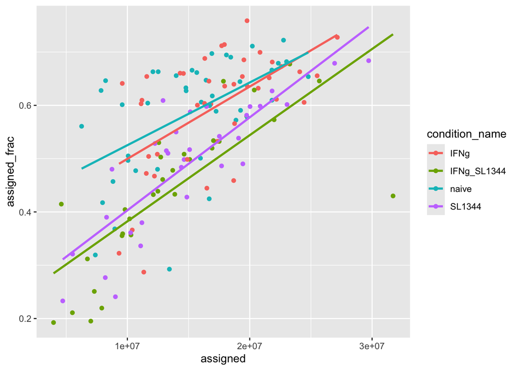

```r
ggplot(
  coldata,
  aes(x = assigned, y = assigned_frac, color = condition_name)
) +
  geom_point() +
  stat_smooth(
    method = "lm",
    formula = "y ~ x",
    se = FALSE
  )
```

**NoteQuestion**

Advanced: try using a different smoothing method, from [?stat_smoooth](https://ggplot2.tidyverse.org/reference/geom_smooth.html).

## Visualizing matrix data

Matrix data, where each column provides a numeric value on the same scale, has specialized plots that helps us understand the structure of the data in the matrix. It often helps to look at transformed data, especially with counts. Below we take the logarithm (base 10) of the data plus a pseudocount of 1. While we can do this operation simply with `log10(matrix + 1)`, here we use a *dplyr* approach, keeping the data in the *tibble* format.

```r
log_counts <- counts |>
  select(-peak) |>
  mutate(across(everything(), ~ log10(.x + 1)))
log_counts_6 <- log_counts |> select(1:6)
```

Alternatively, we could have used more basic R code…

```r
counts_subset <- as.matrix(counts[,2:7])
head( log10(counts_subset + 1) )
```

```
     bima_A_ATAC bima_B_ATAC bima_C_ATAC bima_D_ATAC eofe_A_ATAC eofe_B_ATAC
[1,]    2.453318    2.445604    2.513218    2.451786    2.482874    2.640481
[2,]    1.397940    2.336460    1.653213    1.880814    1.633468    1.892095
[3,]    1.531479    1.740363    1.568202    1.380211    1.322219    1.380211
[4,]    1.653213    1.653213    1.819544    1.568202    1.633468    1.414973
[5,]    1.397940    1.380211    1.255273    1.041393    1.146128    1.000000
[6,]    1.518514    1.518514    1.531479    1.301030    1.505150    1.204120
```

The package *DataExplorer* offers paneled plots across columns of matrix data. For example, to scan across a grid of histograms:

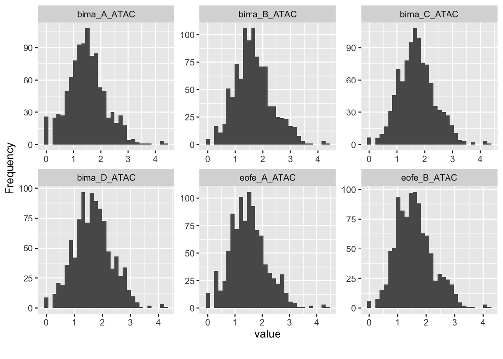

```r
library(DataExplorer)
plot_histogram(log_counts_6, ncol = 3)
```

This is a really useful paradigm to check for samples with different distribution.

What if we have very many samples? We could break the samples into groups of say 12 (4 x 3) and make a PDF with many pages of histograms.

An alternative to this is to use ggplot2’s density function, to draw lines for each sample. But to do so, we must arrange the matrix data into a table, using *tidyr* package and the function `pivot_longer()`. This stacks the matrix columns into a single column, with an additional column specifying the sample name.

Here we will use color to identify sample, but we may have to drop this if we had hundreds of samples.

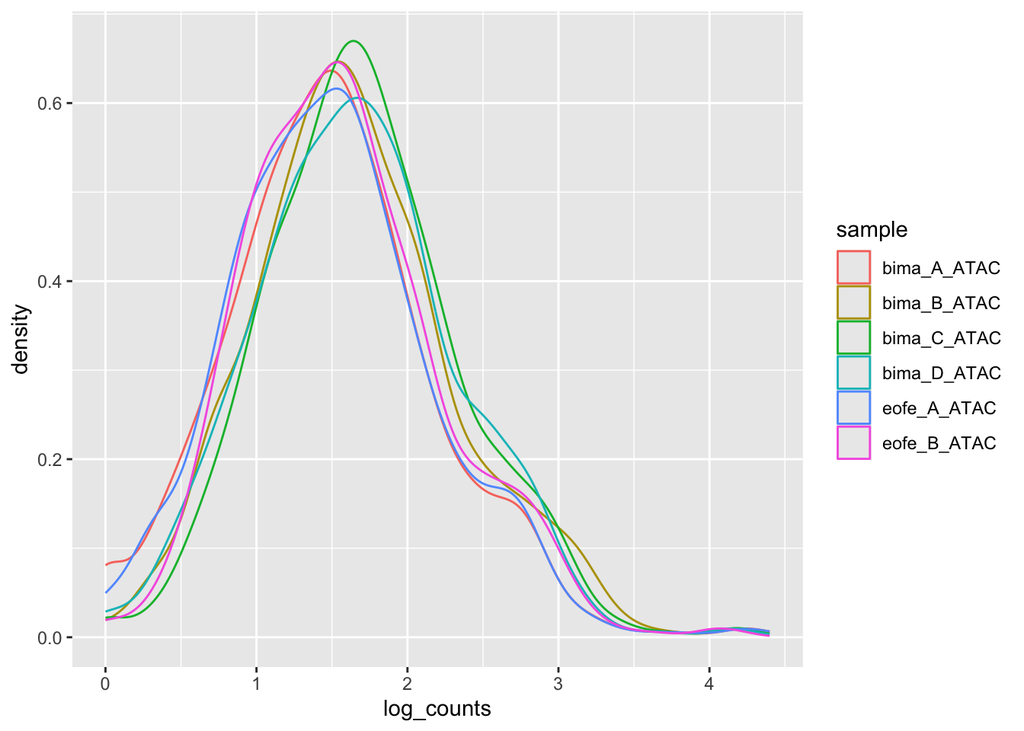

```r
library(tidyr)
long_log_counts <- log_counts_6 |>
  pivot_longer(
    cols = everything(),
    names_to = "sample",
    values_to = "log_counts"
  )
ggplot(
  long_log_counts,
  aes(x = log_counts, color = sample)
) +
  geom_density()
```

Another option would be boxplots or violin plots.

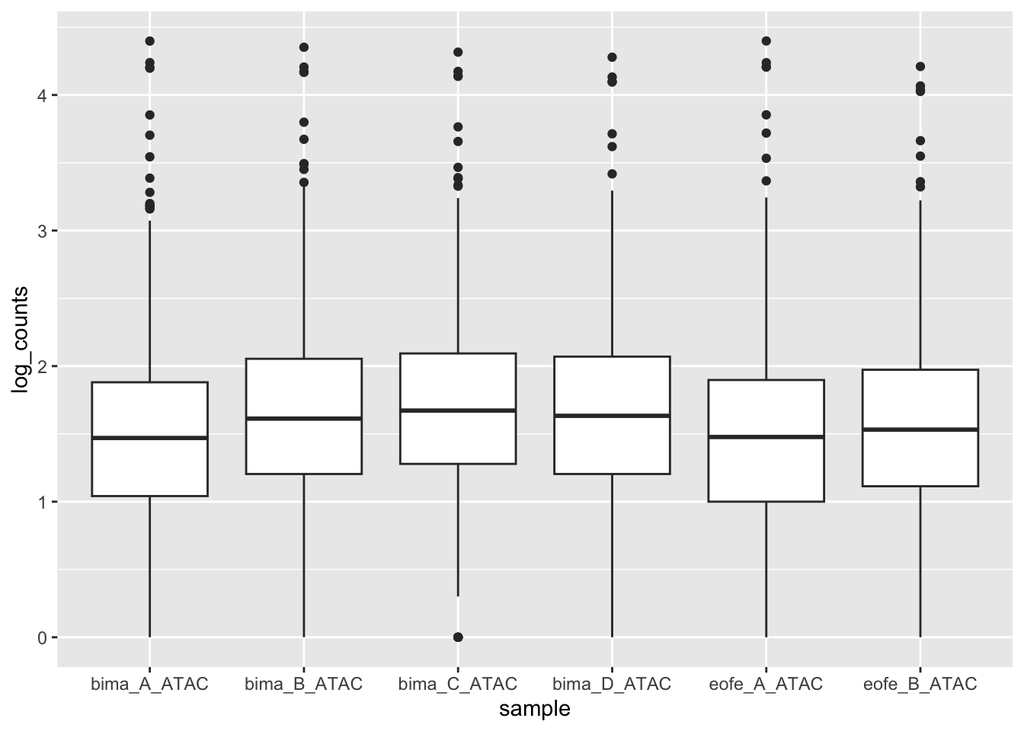

```r
ggplot(
  long_log_counts,
  aes(x = sample, y = log_counts)
) +
  geom_boxplot()
```

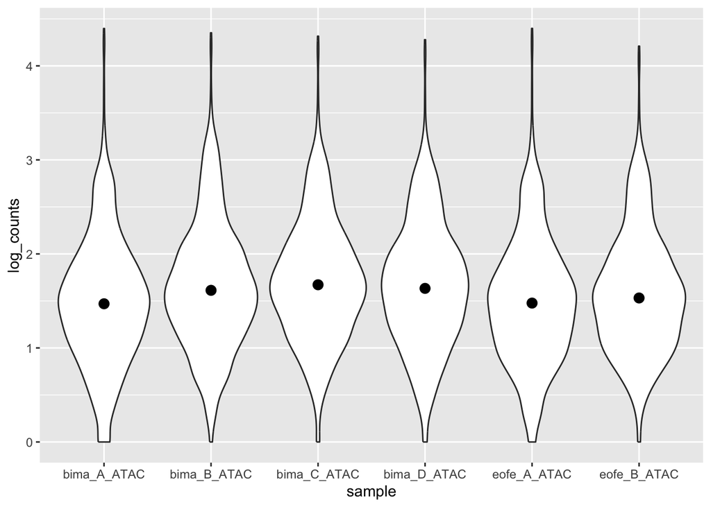

```r
ggplot(
  long_log_counts,
  aes(x = sample, y = log_counts)
) +
  geom_violin() +
  stat_summary(fun = median, geom = "point", size=3)
```

The “QQ-plot” aligns the quantiles of the data with those of a Normal distribution (or another reference distribution). If the values fall roughly on a line, this means the data is roughly normally distributed. I don’t personally use QQ-plots very often, but if you have to compare to a reference distribution for some reason, these are standard.

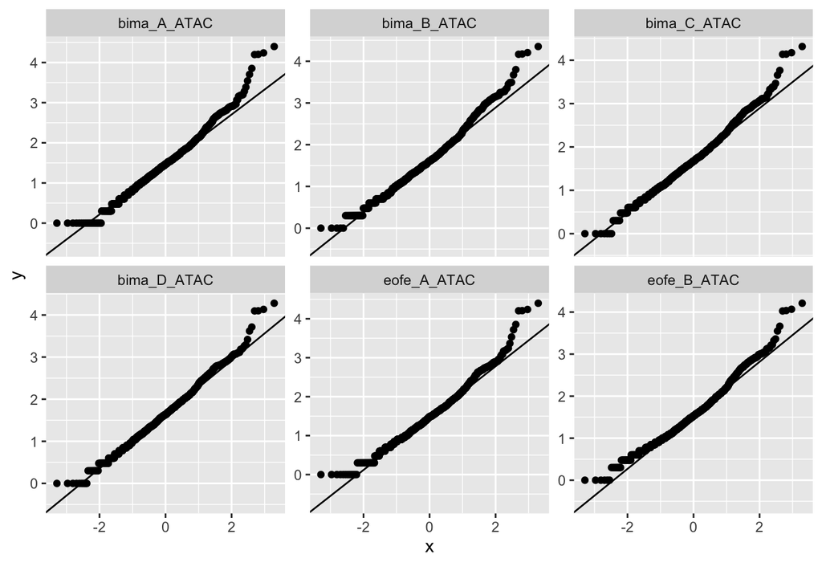

```r
plot_qq(log_counts_6, ncol = 3)
```

We can also make a matrix of correlations:

```r
cormat <- cor(log_counts_6)
range(cormat)
```

```
[1] 0.7222423 1.0000000
```

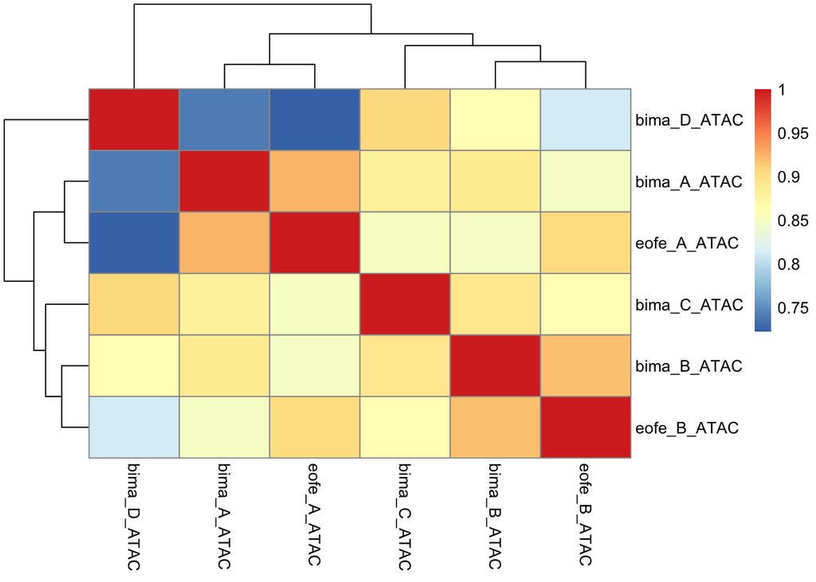

```r
library(pheatmap)
pheatmap(cormat)
```

There are a number of packages that provide more fine-grained correlation matrices, such as [corrgram](https://cran.r-project.org/web/packages/corrgram/vignettes/corrgram_examples.html).

**NoteQuestion**

- What could you say, in broad terms, about the first six samples in terms of these plots (pick whichever plots you want to focus on, e.g. from the colored densities and correlation matrix)?
- For those who are more familiar with omics data such as gene expression and chromatin accessibility: suppose we also read in the gene expression data as a matrix. What might be a way to check that our data is properly aligned by sample across the two assays? What part of a gene must be accessible for it to be expressed? What steps would it take to perform this check?

## Wrangling data into objects

Data wrangling is “the process of transforming and mapping data from one raw data form into another format with the intent of making it more appropriate and valuable for a variety of downstream purposes such as analytics” (from Wikipedia).

For the dataset we have been exploring, we haven’t yet made much use of the annotation of the rows (genome regions) or the columns (samples). We have three separate tables tracking this information, but we don’t even know if the tables are properly aligned (e.g. row 100 in the `peaks` could be row 900 in the `counts` data for all we know, likewise for `coldata` and columns of `counts`). To clean up our code, and prevent potential errors, it makes sense to formally organize our data and metadata across these multiple tables.

First we can do some checks, to make sure samples are present in both tables, and are in the same order. If these are not in order, we will have to re-arrange later.

```r
table(coldata$sample_id %in% colnames(counts)[-1])
```

```
TRUE
 145
```

```r
table(colnames(counts)[-1] %in% coldata$sample_id)
```

```
TRUE
 145
```

```r
# not in order! so we have to be careful below
all.equal(coldata$sample_id, colnames(counts)[-1])
```

```
[1] "63 string mismatches"
```

Again for the rows of the `counts`, i.e. the genomic regions:

```r
table(peaks$gene_id %in% counts$peak)
```

```
TRUE
1000
```

```r
table(counts$peak %in% peaks$gene_id)
```

```
TRUE
1000
```

```r
all.equal(peaks$gene_id, counts$peak)
```

```
[1] TRUE
```

“Object-oriented programming” helps with bookkeeping. The idea is to assemble our tables into a single “object”, which has specific slots and rules for coordinating operations like re-ordering or subsetting across the tables. Putting information into (setting) and pulling information out of (getting) the object will be handled by “accessor” and “assignment” functions. These look like `foo(object)` or `foo(object) <- new_value`.

Below we will create an object to combine and coordinate the `counts` (with rows as genomic regions and columns as samples) with the sample information (`coldata`). We can also add data about the rows (`peaks`).

## Principal component analysis

Principal component analysis (PCA) is a highly useful EDA technique, which rotates our dataset into a new coordinate system. It’s helpful for plotting, diagnostics, machine learning, bias removal, and many more data analytic tasks. We will use it on our chromatin accessibility data to explore how the samples differ in the counts over the regions.

As we have a table with samples as columns, this means we will be rotating our data from the original space of *p* features (the number of rows) into a new space of *p* features where the first features are the most “important”. Mathematically, we can say the first feature will have the most variance, defined as $\frac{1}{n} \sum_i (x_i - \bar{x})^2$, and so on for the second, third, etc. We can also say that taking the top T rotated features are the best at preserving distances in the entire space. So it’s an efficient way to *compress* information into a set of ranked features.

A technical detail before we run PCA: we need to deal with the fact that each column of our matrix has an arbitrary column sum, as we saw before. This tends to not tell us much about the chromatin accessibility, and so hides important biological relationships.

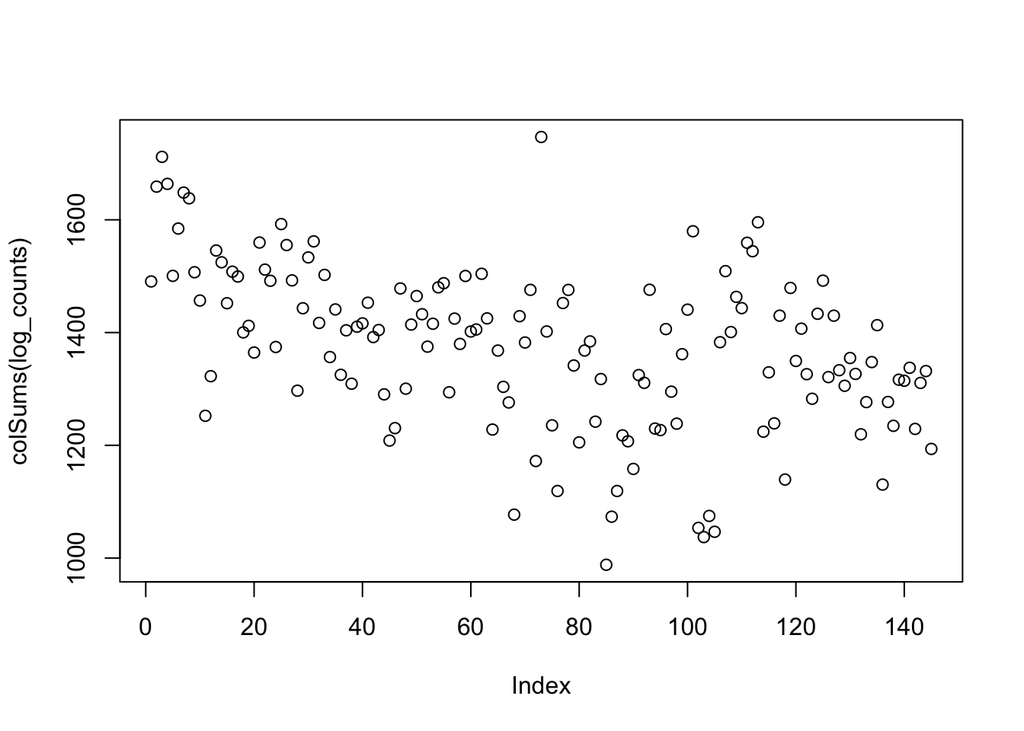

```r
plot(colSums(log_counts))
```

Without getting into too much detail, a decent approach is to simply scale the columns by some value. Here we will scale them by their median value.

```r
scaled_counts <- counts |>
  select(-peak) |>
  mutate(across(everything(),  ~ .x / median(.x))) |>
  as.matrix()
```

Now we compute PCA on the samples. We need to transpose with `t()` to make samples into rows. We take the logarithm (base 10) of the counts in addition, with a pseudocount of 1. There are many considerations about which transformation if any, but something like a logarithm on count data is useful for seeing patterns.

We can immediately make a plot of the data in the rotated space. A 2D scatterplot shows us PC1 and PC2 (`asp = 1` ensures the aspect ratio is kept fixed 1:1).

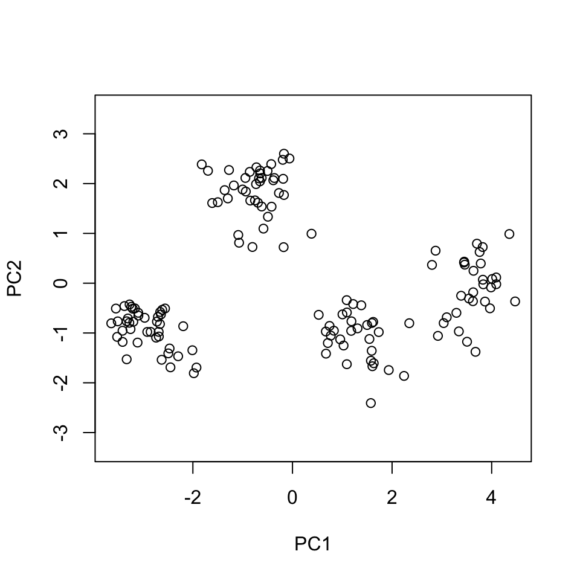

```r
pca <- prcomp(t(log10(scaled_counts + 1)))
plot(pca$x[, 1:2], asp = 1)
```

We can ask, what original features are contributing substantially to these top rotated dimensions?

```r
library(tibble)
rot <- pca$rotation[,1:4] |> as_tibble()
rot |>
  arrange(desc(abs(PC1))) |>
  head()
```

```
# A tibble: 6 × 4
     PC1      PC2      PC3      PC4
   <dbl>    <dbl>    <dbl>    <dbl>
1  0.173 -0.0665  -0.0134  -0.0321
2  0.140 -0.0459  -0.0351  -0.00626
3  0.140 -0.0274  -0.0300  -0.0147
4  0.128 -0.0310  -0.00752 -0.0504
5 -0.123  0.00492  0.00451  0.0274
6  0.122  0.0451  -0.0215  -0.0175
```

And again for PC2:

```r
rot |>
  arrange(desc(abs(PC2))) |>
  head()
```

```
# A tibble: 6 × 4
       PC1   PC2        PC3    PC4
     <dbl> <dbl>      <dbl>  <dbl>
1  0.0596  0.162  0.00627   0.0598
2  0.0509  0.130 -0.0214    0.0582
3  0.0454  0.117  0.0117    0.0478
4 -0.00815 0.112  0.0108    0.0632
5  0.0629  0.108 -0.0126    0.0626
6  0.0442  0.105 -0.0000592 0.0382
```

However, this analysis would be much more valuable if we had sample and feature metadata alongside. Let’s arrange the `coldata` so it matches the columns of `counts`:

```r
coldata_arr <- coldata |>
  arrange(match(sample_id, colnames(counts)[-1]))
```

Now we can put the `counts` and its column data together into an object. We can use the *SummarizedExperiment* package to build an object of the same name. This will tie together the two tables and facilitate data manipulation and plotting.

```r
library(SummarizedExperiment)
se <- SummarizedExperiment(
  list(counts = counts |> select(-1) |> as.matrix()),
  colData = coldata_arr
)
se
```

```
class: SummarizedExperiment
dim: 1000 145
metadata(0):
assays(1): counts
rownames: NULL
rowData names(0):
colnames(145): bima_A_ATAC bima_B_ATAC ... zaui_C_ATAC zaui_D_ATAC
colData names(47): sample_id donor ... short_long_ratio peak_count
```

We can access variables about the rows and columns with `rowData` and `colData`. There is also a shortcut for accessing variables about the columns, simply using a `$` and the variable name:

```r
head( se$sample_id )
```

```
[1] "bima_A_ATAC" "bima_B_ATAC" "bima_C_ATAC" "bima_D_ATAC" "eofe_A_ATAC" "eofe_B_ATAC"
```

```r
# same as
head( colData(se)$sample_id )
```

```
[1] "bima_A_ATAC" "bima_B_ATAC" "bima_C_ATAC" "bima_D_ATAC" "eofe_A_ATAC" "eofe_B_ATAC"
```

Additionally, I will define an ordering of the conditions, and define a new variable about the samples, `condition`:

```r
fct_lvls <- c("naive","IFNg","SL1344","IFNg_SL1344")
se$condition <- factor( se$condition_name, fct_lvls )
table( se$condition )
```

```
      naive        IFNg      SL1344 IFNg_SL1344
         42          41          31          31
```

Another benefit to building such an object is that there are many R/Bioconductor packages that take in such an annotated matrix object. The DESeq2 package allows us to quickly scale, transform, and plot the data with a few lines of code. We avoid potential issues with the tables getting out of orer, as the entire object is passed from one line to the other (`dds` is just another type of SummarizedExperiment here).

```
using ntop=500 top features by variance
```

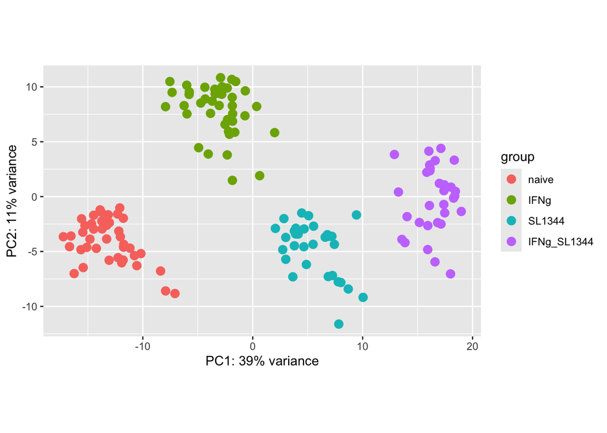

```r
library(DESeq2)
dds <- DESeqDataSet(se, ~condition)
dds <- estimateSizeFactors(dds)
vsd <- varianceStabilizingTransformation(dds)
plotPCA(vsd, intgroup="condition")
```

**NoteQuestion**

What do you observe in the PCA plot colored by sample condition?

We actually have three aligned tables (remember, `peaks` and `counts` were already aligned by row). Let’s add the peak data

```r
peaks <- peaks |>
  select(
    chr,
    start,
    end,
    strand,
    peak_id = gene_id,
    perc_gc
  )
rowData(se) <- peaks
rowData(se)
```

```
DataFrame with 1000 rows and 6 columns
           chr     start       end      strand        peak_id   perc_gc
     <numeric> <numeric> <numeric> <character>    <character> <numeric>
1            1      9979     10668           +    ATAC_peak_1  0.555072
2            1     10939     11473           +    ATAC_peak_2  0.674766
3            1     15505     15729           +    ATAC_peak_3  0.617778
4            1     21148     21481           +    ATAC_peak_4  0.571856
5            1     21864     22067           +    ATAC_peak_5  0.558824
...        ...       ...       ...         ...            ...       ...
996          1   8328316   8328473           +  ATAC_peak_996  0.588608
997          1   8349052   8349253           +  ATAC_peak_997  0.673267
998          1   8351796   8351933           +  ATAC_peak_998  0.615942
999          1   8371011   8371201           +  ATAC_peak_999  0.476440
1000         1   8373970   8374329           + ATAC_peak_1000  0.536111
```

I will annotate the rows of the `se` object:

```r
rownames(se) <- rowData(se)$peak_id
```

Next we will use the information about location of the genomic regions, to enable more sophisticated downstream EDA.

## Advanced case study: chromatin accessibility

The following is a more advanced lab, which assumes some knowledge of genomics and computational biology. Feel free to stop here, or explore the rest. Ask TAs or instructors if you want more information, or you can also ask various AI chatbots, as this is a very well studied dataset with multiple papers and tutorials built upon it, and thematically examining chromatin accessibility across sample conditions (including immune stimulation) is a common genomics task.

In the following case study, we briefly explore the chromatin accessibility in these 1,000 genomic regions. We will make use of the PCA results, and PC1 which apparently highlights regions that distinguish the naive condition from the immune response conditions (in particular the combined treatment).

First we compute PCA on the transformed data.

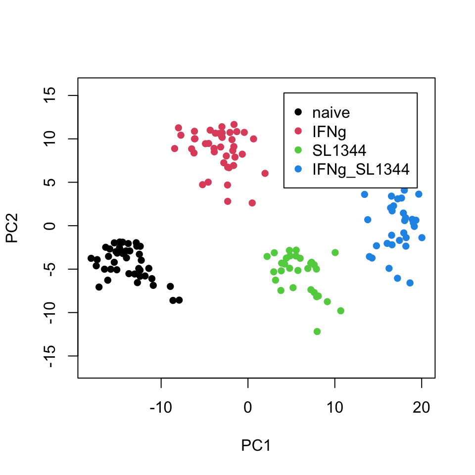

```r
pca <- prcomp(t(assay(vsd)))
# base R PCA plot can be made with:
plot(pca$x[, 1:2], col = vsd$condition, pch = 16, asp = 1)
legend(
  "topright",
  levels(vsd$condition),
  col = vsd$condition,
  pch = 16,
  inset = .05
)
```

Examining the top features contributing to PC1 (in absolute value):

```r
rot <- pca$rotation[,1:4] |> as_tibble()
rot |>
  arrange(desc(abs(PC1))) |>
  head()
```

```
# A tibble: 6 × 4
    PC1     PC2      PC3       PC4
  <dbl>   <dbl>    <dbl>     <dbl>
1 0.144 -0.0578  0.00976 -0.0276
2 0.129 -0.0320  0.0112  -0.00507
3 0.129 -0.0476  0.0158  -0.000589
4 0.111 -0.0326  0.0130  -0.0412
5 0.110 -0.0573  0.00471 -0.00106
6 0.108 -0.0362 -0.00587  0.0391
```

```r
pc1_features <- order(abs(rot$PC1), decreasing=TRUE) |> head(10)
```

Plotting the scaled counts for some of the top features of PC1:

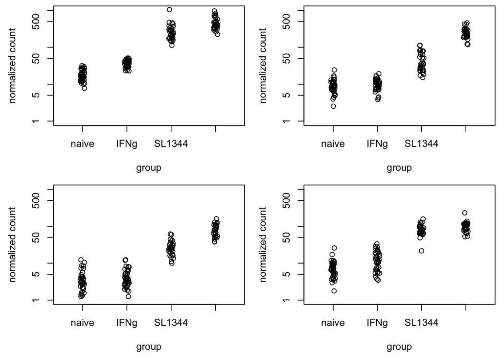

```r
par(mfrow = c(2, 2), mar = c(4.5, 4.5, .5, .5))
for (i in c(1,3,5,7)) {
  plotCounts(
    dds,
    gene = pc1_features[i],
    intgroup = "condition",
    ylim=c(1, 1000)
  )
}
```

**NoteQuestion**

What pattern does PC1 represent across these highlighted peaks?

Doing the same for random features:

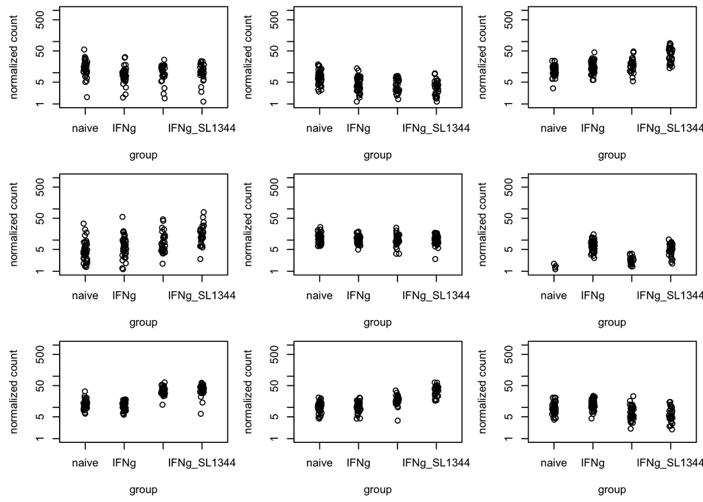

```r
set.seed(5)
par(mfrow = c(3, 3), mar = c(4.5, 4.5, .5, .5))
for (i in sample(1000, 9)) {
  plotCounts(
    dds,
    gene = i,
    intgroup = "condition",
    ylim = c(1, 1000)
  )
}
```

```r
# reset the plotting par
par(mfrow = c(1, 1), mar = c(4.5, 4.5, 1, 1))
```

Saving our genomic regions as a genomic range (*GRanges* object) called `p`.

The *plyranges* package is part of the [tidyomics project](https://github.com/tidyomics) and allows the use of *dplyr* syntax on specialized objects for genomics. Note also *plyranges* has import functions such as `read_bed`, `read_narrowpeaks`, `read_bigwig`, etc.

```r
library(plyranges)
p <- peaks |>
  as_granges(seqnames = chr)
p
```

```
GRanges object with 1000 ranges and 2 metadata columns:
         seqnames          ranges strand |        peak_id   perc_gc
            <Rle>       <IRanges>  <Rle> |    <character> <numeric>
     [1]        1      9979-10668      + |    ATAC_peak_1  0.555072
     [2]        1     10939-11473      + |    ATAC_peak_2  0.674766
     [3]        1     15505-15729      + |    ATAC_peak_3  0.617778
     [4]        1     21148-21481      + |    ATAC_peak_4  0.571856
     [5]        1     21864-22067      + |    ATAC_peak_5  0.558824
     ...      ...             ...    ... .            ...       ...
   [996]        1 8328316-8328473      + |  ATAC_peak_996  0.588608
   [997]        1 8349052-8349253      + |  ATAC_peak_997  0.673267
   [998]        1 8351796-8351933      + |  ATAC_peak_998  0.615942
   [999]        1 8371011-8371201      + |  ATAC_peak_999  0.476440
  [1000]        1 8373970-8374329      + | ATAC_peak_1000  0.536111
  -------
  seqinfo: 1 sequence from an unspecified genome; no seqlengths
```

**NoteQuestion**

This object `p` that we just created has missing `seqinfo` – explore with `seqinfo(p)`. Why would it be useful to always work with data that has a specified genome with chromosome lengths?

Adding PC1 loadings (the rotation information) and an absolute-valued and scaled version of PC1:

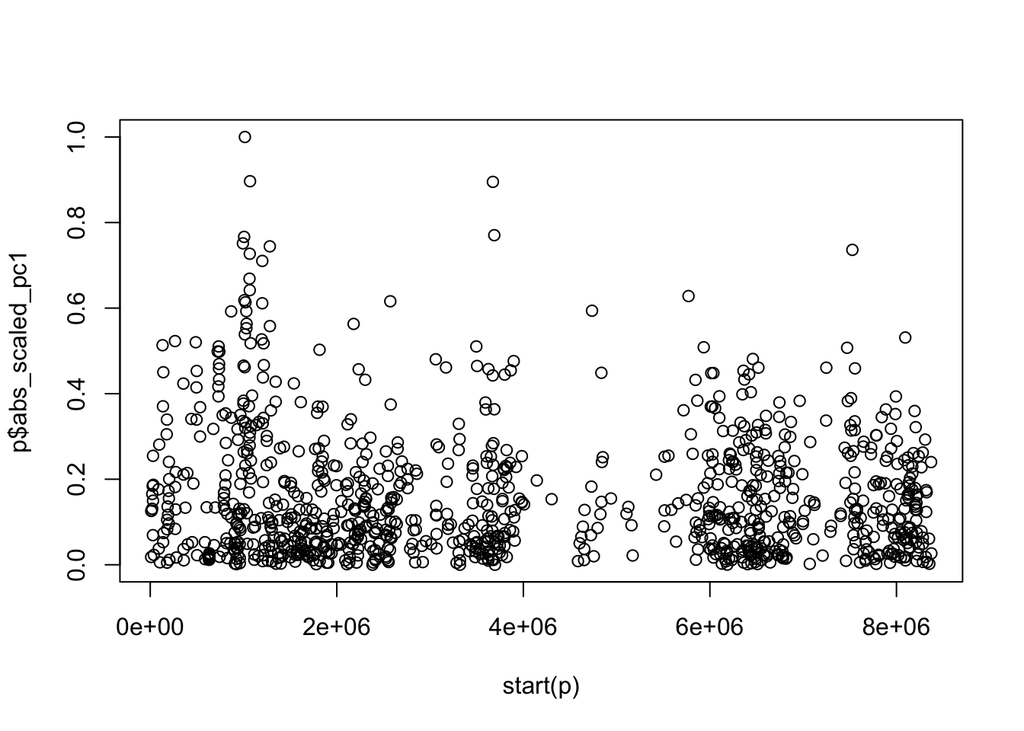

```r
p <- p |>
  mutate(
    pc1 = rot[, "PC1", drop = TRUE],
    abs_scaled_pc1 = abs(pc1)/max(abs(pc1))
  )
plot(start(p), p$abs_scaled_pc1)
```

Suppose we want to know about which regions have high values contributing to PC1, in terms of tiles of 10,000 bp along this region:

```r
tiles <- range(p) |>
  tile_ranges(width = 1e4) %>%
  mutate(id = seq_along(.))
tiles
```

```
GRanges object with 837 ranges and 2 metadata columns:
        seqnames          ranges strand | partition        id
           <Rle>       <IRanges>  <Rle> | <integer> <integer>
    [1]        1      9979-19971      + |         1         1
    [2]        1     19972-29964      + |         1         2
    [3]        1     29965-39957      + |         1         3
    [4]        1     39958-49951      + |         1         4
    [5]        1     49952-59944      + |         1         5
    ...      ...             ...    ... .       ...       ...
  [833]        1 8324363-8334355      + |         1       833
  [834]        1 8334356-8344349      + |         1       834
  [835]        1 8344350-8354342      + |         1       835
  [836]        1 8354343-8364335      + |         1       836
  [837]        1 8364336-8374328      + |         1       837
  -------
  seqinfo: 1 sequence from an unspecified genome; no seqlengths
```

Syntax note: in the above code chunk, I use `%>%` at one point instead of `|>`. This minor detail is because only `%>%` allows for the use of `.` nested within a function (here nested within `mutate`). For the most part `|>` and `%>%` are exchangeable, with `|>` slightly preferred as it is part of base R.

See also `slide_ranges` in *plyranges* package, and `tileGenome` in the *GenomicRanges* package.

We can look at the summarized amount of PC1 contribution in each tile. Overlaps in *plyranges* can be computed as follows. Note that many options exist here, including `_directed` (strand-specific), `_within`, `maxgap`, `minoverlap`, etc.

```r
tiles |>
  join_overlap_left(p)
```

```
GRanges object with 1410 ranges and 6 metadata columns:
         seqnames          ranges strand | partition        id        peak_id   perc_gc
            <Rle>       <IRanges>  <Rle> | <integer> <integer>    <character> <numeric>
     [1]        1      9979-19971      + |         1         1    ATAC_peak_1  0.555072
     [2]        1      9979-19971      + |         1         1    ATAC_peak_2  0.674766
     [3]        1      9979-19971      + |         1         1    ATAC_peak_3  0.617778
     [4]        1     19972-29964      + |         1         2    ATAC_peak_4  0.571856
     [5]        1     19972-29964      + |         1         2    ATAC_peak_5  0.558824
     ...      ...             ...    ... .       ...       ...            ...       ...
  [1406]        1 8344350-8354342      + |         1       835  ATAC_peak_997  0.673267
  [1407]        1 8344350-8354342      + |         1       835  ATAC_peak_998  0.615942
  [1408]        1 8354343-8364335      + |         1       836           <NA>        NA
  [1409]        1 8364336-8374328      + |         1       837  ATAC_peak_999  0.476440
  [1410]        1 8364336-8374328      + |         1       837 ATAC_peak_1000  0.536111
                  pc1 abs_scaled_pc1
            <numeric>      <numeric>
     [1]   0.00261249       0.018152
     [2]   0.01809885       0.125754
     [3]  -0.01825119       0.126813
     [4]  -0.01884690       0.130952
     [5]  -0.02381251       0.165454
     ...          ...            ...
  [1406]  0.008774674     0.06096803
  [1407] -0.000337387     0.00234422
  [1408]           NA             NA
  [1409] -0.034553812     0.24008620
  [1410]  0.003823071     0.02656339
  -------
  seqinfo: 1 sequence from an unspecified genome; no seqlengths
```

```r
# NA indicates no overlap...
# can be dropped with join_overlap_inner()
```

Adding together with grouping and summarization:

```r
tab <- tiles |>
  join_overlap_left(p) |>
  group_by(id) |>
  summarize(
    n_overlaps = sum(!is.na(peak_id)), # has overlap
    sum_pc1 = sum(abs_scaled_pc1, na.rm=TRUE)
  ) |>
  as_tibble()
tab
```

```
# A tibble: 837 × 3
      id n_overlaps sum_pc1
   <int>      <int>   <dbl>
 1     1          3 0.271
 2     2          6 0.955
 3     3          3 0.465
 4     4          0 0
 5     5          0 0
 6     6          0 0
 7     7          0 0
 8     8          1 0.176
 9     9          2 0.319
10    10          1 0.00572
# ℹ 827 more rows
```

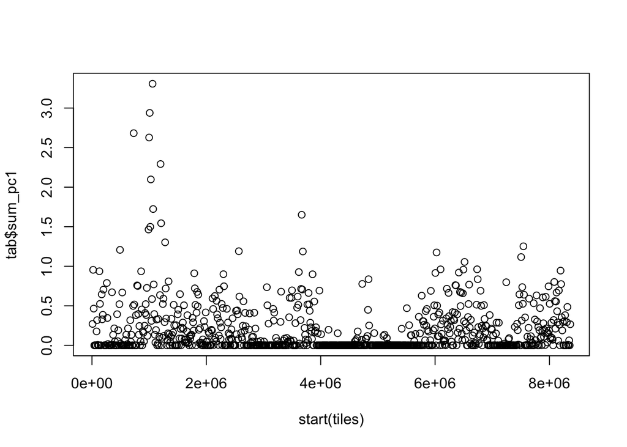

```r
plot(start(tiles), tab$sum_pc1)
```

Note: for more examples of using *plyranges* to manipulate genomic regions in R, see my [tidy ranges tutorial](https://tidyomics.github.io/tidy-ranges-tutorial/).

Note: For examples of plotting genomic data, see [plotgardener](https://phanstiellab.github.io/plotgardener/) for enabling complex plots with multiple components, and [wiggleplotr](https://bioconductor.org/packages/wiggleplotr/) for simple gene plots.

**NoteQuestion**

Is there any relationship between the GC content (`gc`) and the contribution to PC1 in tiles?

Which tile has the highest summarized contribution to PC1? Which peaks are contributing to this tile?

```r
which.max(tab$sum_pc1)
```

```
[1] 106
```

```r
tab |> dplyr::slice(which.max(sum_pc1))
```

```
# A tibble: 1 × 3
     id n_overlaps sum_pc1
  <int>      <int>   <dbl>
1   106          8    3.31
```

```r
max_tile <- tiles |> dplyr::slice(which.max(tab$sum_pc1))
p |>
  filter_by_overlaps(max_tile)
```

```
GRanges object with 8 ranges and 4 metadata columns:
      seqnames          ranges strand |       peak_id   perc_gc       pc1 abs_scaled_pc1
         <Rle>       <IRanges>  <Rle> |   <character> <numeric> <numeric>      <numeric>
  [1]        1 1059227-1059777      + | ATAC_peak_157  0.771325 0.0308880       0.214616
  [2]        1 1059840-1059926      + | ATAC_peak_158  0.735632 0.0243494       0.169184
  [3]        1 1063910-1064089      + | ATAC_peak_159  0.744444 0.0428207       0.297526
  [4]        1 1064187-1064553      + | ATAC_peak_160  0.686648 0.0962591       0.668826
  [5]        1 1065904-1066081      + | ATAC_peak_161  0.528090 0.0401471       0.278949
  [6]        1 1066809-1066992      + | ATAC_peak_162  0.657609 0.1046371       0.727038
  [7]        1 1067064-1067251      + | ATAC_peak_163  0.510638 0.0923891       0.641936
  [8]        1 1069109-1069645      + | ATAC_peak_164  0.731844 0.0444586       0.308907
  -------
  seqinfo: 1 sequence from an unspecified genome; no seqlengths
```

## Advanced case study: bootstrapping genomic data

A final code chunk demonstrates how we might begin to ask about our observed sequence with respect to *null* data. We can take the original data and randomize it using the bootstrap. For more details see the *bootRanges* vignette in the *nullranges* package, or in the [bootstrap chapter](https://tidyomics.github.io/tidy-ranges-tutorial/bootstrap-overlap.html) of *tidy ranges tutorial*.

This code below creates 10 bootstrapped versions of the peaks data, and assesses how often we see as large a summarized PC1 value for a particular tile we highlighted above.

In a more realistic analysis, I might use an anchored set of features in lieu of `max_tile` here. For example, a pre-defined set of regions of interest, such as genes related to immune response.

```r
library(nullranges)
seqlengths(p) <- c("1" = 9e6) # just for demo
boot <- bootRanges(p, blockLength = 1e5, R = 10)
res_ovrlp <- boot |>
  filter_by_overlaps(max_tile) |>
  group_by(iter) |>
  summarize(
    n_overlaps = n(),
    sum_pc1 = sum(abs_scaled_pc1)
  ) |>
  as_tibble()
res_ovrlp
```

```
# A tibble: 5 × 3
  iter  n_overlaps sum_pc1
  <fct>      <int>   <dbl>
1 1              4  0.794
2 3              4  0.173
3 5              1  0.0267
4 6              2  0.174
5 9              1  0.520
```

We can use `complete()` from *tidyr* to fill in the missing iterations (had no overlap):

```r
res_ovrlp |>
  tidyr::complete(
    iter,
    fill = list(n_overlaps = 0, sum_pc1 = 0)
  )
```

```
# A tibble: 10 × 3
   iter  n_overlaps sum_pc1
   <fct>      <int>   <dbl>
 1 1              4  0.794
 2 2              0  0
 3 3              4  0.173
 4 4              0  0
 5 5              1  0.0267
 6 6              2  0.174
 7 7              0  0
 8 8              0  0
 9 9              1  0.520
10 10             0  0
```

This concludes the brief case study of exploring omics data in genomic context, and in the following appendix, I show some alternative packages and functions that you may find useful for EDA.

## Appendix

### Tidy operations on rich objects

The following code chunks show how we can use new packages in the *tidyomics* project (within Biconductor), to manipulate objects using *dplyr*-like syntax.

```r
library(SummarizedExperiment)
se_thin <- se
cols <- c("donor","condition","mean_purity","assigned","peak_count")
colData(se_thin) <- colData(se_thin)[,cols]
```

```r
library(plyxp)
xp <- new_plyxp(se_thin) |>
  mutate(
    log_scaled_counts = log2(counts/.cols$assigned + 1),
    rows(row_sums = rowSums(.assays_asis$counts))
  )
```

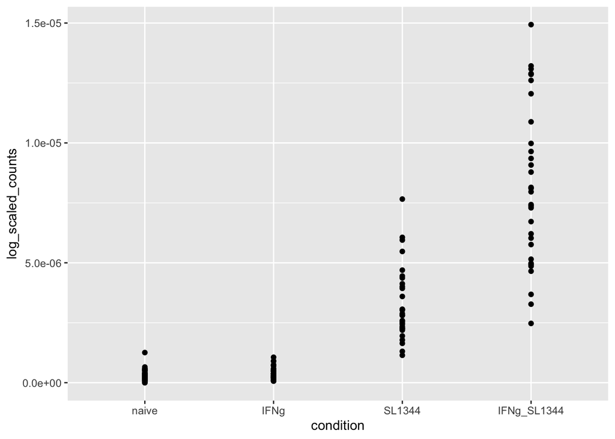

```r
library(tidySummarizedExperiment)
xp |>
  filter(rows(peak_id == "ATAC_peak_162")) |>
  se() |>
  ggplot(aes(condition, log_scaled_counts)) +
  geom_point()
```

### iSEE - interactive exploratory applications

*iSEE* is a Bioconductor package (with many associated packages) that allows for interactive visualization of data objects. You can try it out with the following:

```r
library(iSEE)
iSEE(se_thin)
```

### Missing data toolkit

Identifying and characterizing missingness is important! The *naniar* package helps to deal with and visualize patterns of missingness. As our above worked example dataset doesn’t contain very many missing values, here I simulate a dataset with missingness.

```r
library(naniar)
dat_with_na <- tibble(
  foo = rnbinom(500, mu=20, size=5),
  bar = rnbinom(500, mu=20, size=5)
)
dat_with_na <- dat_with_na |>
  mutate(across(
    everything(),
    ~ {
      na_idx <- sample(length(.x), 100)
      .x[na_idx] <- NA
      .x
    }))
```

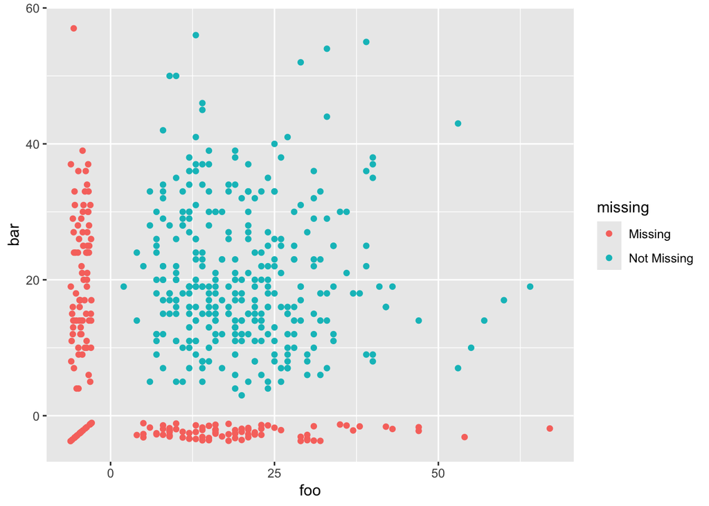

```r
library(ggplot2)
ggplot(dat_with_na, aes(foo, bar)) +
  geom_miss_point()
```

```r
dat_with_na |>
  bind_shadow()
```

```
# A tibble: 500 × 4
     foo   bar foo_NA bar_NA
   <dbl> <dbl> <fct>  <fct>
 1     8    17 !NA    !NA
 2    26    21 !NA    !NA
 3    16    12 !NA    !NA
 4    NA    12 NA     !NA
 5    32    NA !NA    NA
 6    10    35 !NA    !NA
 7    13    NA !NA    NA
 8    60    17 !NA    !NA
 9    33     7 !NA    !NA
10    22    11 !NA    !NA
# ℹ 490 more rows
```

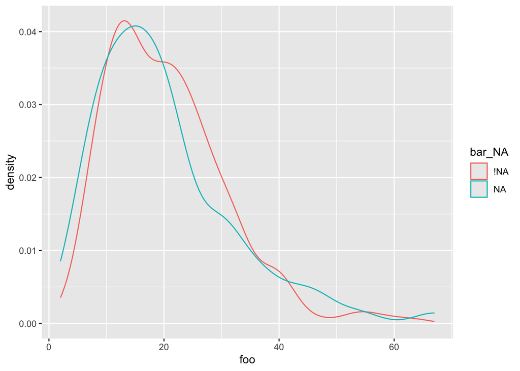

```r
dat_with_na |>
  bind_shadow() |>
  ggplot(aes(foo, color = bar_NA)) +
  geom_density()
```

### summarytools

The *summarytools* package provides alternative summaries, a bit more verbose than the ones above.

```r
library(summarytools)
descr(peaks) # simple table, like skim
dfSummary(peaks) # pop-up descriptive page
```

It also allows for pop-out summary tables, within an RStudio session:

```r
view(dfSummary(peaks)) # RStudio
```